# RNAseq_analysis-EZH2

Christine Gao

5/4/2023

Function for retrieving gene names, given a vector of Ensembl IDs. Returns a dataframe containing both Ensembl IDs and corresponding genes. **Leaves out Ensembl IDs for which a gene name could not be found.

```r
get.gene <- function(x){
  ensembl102.mmusculus <- useEnsembl(biomart='genes', dataset='mmusculus_gene_ensembl', version=102)
  mgi <- getBM(attributes=c('ensembl_gene_id','mgi_symbol'),
               filters='ensembl_gene_id',
               values=x,
               mart=ensembl102.mmusculus)
  genes <- data.frame(ensembl_gene_id=x)
  genes <- merge(genes, mgi, by='ensembl_gene_id')
  return(genes)
}
```

Function for retrieving homologous mouse Ensembl IDs, given a vector of human Ensembl IDs. Returns a dataframe of matching mouse and human Ensembl IDs. Leaves out human Ensembl IDs for which a mouse homolog could not be found.

```r
get.mouseHomolog <- function(human.EnsemblID){
  human <- useMart('ensembl', dataset='hsapiens_gene_ensembl')
  searchAttributes(human, pattern='mmusculus')
  human.mouse.homologs <- getBM(attributes = c("ensembl_gene_id", "external_gene_name",
                                               "mmusculus_homolog_ensembl_gene",
                                               "mmusculus_homolog_associated_gene_name",
                                               "mmusculus_homolog_orthology_confidence",
                                               "mmusculus_homolog_perc_id_r1"),
                                filters = "ensembl_gene_id",
                                values = human.EnsemblID,
                                mart = human)
  human.mouse.homologs <- human.mouse.homologs[
    which(human.mouse.homologs$mmusculus_homolog_orthology_confidence==1),]
  mouse.EnsemblID <- data.frame(mouse=human.mouse.homologs$mmusculus_homolog_ensembl_gene,
                                human=human.mouse.homologs$ensembl_gene_id)
  return(mouse.EnsemblID)
}
```

Use data from ENCODE Txn Factor ChIP track, downloaded from UCSC: http://hgdownload.soe.ucsc.edu/goldenPath/hg19/encodeDCC/wgEncodeRegTfbsClustered/  
Identify EZH2 binding sites across human cell lines and create hg19 GRanges object.

```r
bed <- as.data.frame(read.table('wgEncodeRegTfbsClusteredWithCellsV3.bed',
                                header = FALSE, sep="\t", stringsAsFactors=FALSE, quote=""))
colnames(bed) <- c('chrom','chromStart','chromEnd','factor','score','cell')

bed$sourceCount <- lengths(str_split(bed$cell, ',')) # number of cell lines with peaks
bed_EZH2 <- bed[which(bed$factor=='EZH2'),]
table(unlist(str_split(bed_EZH2$cell, ','))) # total number of EZH2 peaks per cell line
```

```
##
##    Dnd41  GM12878  H1-hESC  HeLa-S3    HepG2     HMEC     HSMM HSMMtube
##     1349     2216     3039     1661     2526     2984     1185     1893
##    HUVEC     K562     NH-A  NHDF-Ad     NHEK     NHLF
##     3196     1621     3514     2958     4497     3960
```

```r
GRanges.hg19.EZH2 <- makeGRangesFromDataFrame(bed_EZH2, keep.extra.columns=TRUE)
genome(GRanges.hg19.EZH2) <- 'hg19'
save(GRanges.hg19.EZH2, file='GRanges.hg19.EZH2.rda')
```

Stratify EZH2 peak GRanges by level of evidence (number of cell lines with concordant peaks).

```r
EZH2.all <- GRanges.hg19.EZH2
EZH2.mod <- GRanges.hg19.EZH2[which(GRanges.hg19.EZH2$sourceCount >= 2)]
EZH2.strong <- GRanges.hg19.EZH2[which(GRanges.hg19.EZH2$sourceCount >= 5)]
```

Obtain GRanges of all hg19 gene promoters.

```r
edb <- EnsDb.Hsapiens.v75
prom.all <- promoters(edb, upstream=2000, downstream=2000,
                       columns = c("gene_name", "tx_id", "tx_cds_seq_start", "tx_cds_seq_end",
                                   "tx_biotype", "gene_id"))
genome(seqinfo(prom.all)) <- 'hg19'
seqlevelsStyle(prom.all) <- 'ucsc'
prom.all <- prom.all[which(seqnames(prom.all) %in% names(Hsapiens)[1:24])]
```

Find overlaps between EZH2 peaks and hg19 gene promoters. For each hg19 promoter hit, keep the max EZH2 peak score and corresponding number of cell line sources.

```r
human.target.all <- data.frame(human=prom.all$gene_id[queryHits(findOverlaps(prom.all, EZH2.all))],
                               EZH2.score=EZH2.all$score[subjectHits(findOverlaps(prom.all, EZH2.all))],
                               sources=EZH2.all$sourceCount[
                                 subjectHits(findOverlaps(prom.all, EZH2.all))])
human.target.all <- data.frame(human.target.all %>%
                                 group_by(human) %>%
                                 slice_max(EZH2.score, with_ties = FALSE))

human.target.mod <- data.frame(human=prom.all$gene_id[queryHits(findOverlaps(prom.all, EZH2.mod))],
                               EZH2.score=EZH2.mod$score[subjectHits(findOverlaps(prom.all, EZH2.mod))],
                               sources=EZH2.mod$sourceCount[
                                 subjectHits(findOverlaps(prom.all, EZH2.mod))])
human.target.mod <- data.frame(human.target.mod %>%
                                 group_by(human) %>%
                                 slice_max(EZH2.score, with_ties = FALSE))

human.target.strong <- data.frame(human=
                                    prom.all$gene_id[queryHits(findOverlaps(prom.all, EZH2.strong))],
                                  EZH2.score=
                                    EZH2.strong$score[subjectHits(findOverlaps(prom.all, EZH2.strong))],
                                  sources=EZH2.strong$sourceCount[
                                    subjectHits(findOverlaps(prom.all, EZH2.strong))])
human.target.strong <- data.frame(human.target.strong %>%
                                    group_by(human) %>%
                                    slice_max(EZH2.score, with_ties = FALSE))
```

Get mouse homologs for hg19 promoter hits.

```r
mouse.target.all <- get.mouseHomolog(human.target.all$human)
mouse.target.all <- merge(mouse.target.all, human.target.all, by='human', all=FALSE)

mouse.target.mod <- get.mouseHomolog(human.target.mod$human)
mouse.target.mod <- merge(mouse.target.mod, human.target.mod, by='human', all=FALSE)

mouse.target.strong <- get.mouseHomolog(human.target.strong$human)
mouse.target.strong <- merge(mouse.target.strong, human.target.strong, by='human', all=FALSE)
head(mouse.target.strong)
```

```
##             human              mouse EZH2.score sources
## 1 ENSG00000002745 ENSMUSG00000029671        730       7
## 2 ENSG00000002746 ENSMUSG00000021301        616       9
## 3 ENSG00000002933 ENSMUSG00000023367        566       8
## 4 ENSG00000003137 ENSMUSG00000063415       1000      11
## 5 ENSG00000004468 ENSMUSG00000029084        471       6
## 6 ENSG00000004848 ENSMUSG00000035277        585      10
```

Load ost and bmp genes of interest. Merge with mouse homologs of hg19 EZH2 target promoters.

```r
ost <- read.csv('ost-list.csv')
ost <- ost[,-1]
colnames(ost)[1] <- 'mouse'
ost.EZH2 <- merge(ost, mouse.target.all, by='mouse')
ost.EZH2[order(-ost.EZH2$EZH2.score, -ost.EZH2$log2FC.MutDMSO.WtDMSO),
         !(names(ost.EZH2) %in% c('mouse','human'))]
```

```
##    mgi_symbol log2FC.MutDMSO.WtDMSO log2FC.MutGSKJ4.MutDMSO EZH2.score sources
## 15      Pth1r             0.8203454              -0.6081632       1000       9
## 18      Satb2             0.7320210              -0.9144421       1000       8
## 10      Shox2             0.4893751              -0.3354982       1000       8
## 20      Runx2             0.4807406              -0.4955014       1000       1
## 12       Dlx5             0.3658963              -0.4156353        940       4
## 16     Twist1             0.4050091              -0.3457663        853       5
## 17       Fgf2            -0.5332390               0.4303906        795       3
## 6        Msx2             0.5758012              -0.4374575        757       2
## 11     Tgfbr3            -0.1869117              -0.2760733        699       4
## 21       Hey1             0.6711570              -0.6916543        604       3
## 7       Vegfa             0.5781129              -0.5781219        530       1
## 5       Ptch1             0.3679175              -0.4058430        516       2
## 9     Creb3l1             0.8104102              -0.7606586        501       3
## 14      Smad3             0.3300772              -0.4466427        498       1
## 1        Sox9             0.7508040              -1.0031158        469       3
## 8       Bambi             0.9566960              -0.6655395        411       5
## 13      Sfrp1            -0.9284358               0.2596683        380       4
## 19     Scube3             0.8242980              -1.0352849        362       3
## 2       Mef2c             0.8633266              -0.6785221        354       1
## 22        Sp7             0.6323921              -0.5879897        304       1
## 3      Ctnnb1             0.1920743              -0.2034781        241       1
## 4        Fhl2            -0.5064987               0.2717879        136       1
```

```r
bmp <- read.csv('bmp-list.csv')
bmp <- bmp[,-1]
colnames(bmp)[1] <- 'mouse'
bmp.EZH2 <- merge(bmp, mouse.target.all, by='mouse')
bmp.EZH2[order(-bmp.EZH2$EZH2.score, -bmp.EZH2$log2FC.MutDMSO.WtDMSO),
         !(names(bmp.EZH2) %in% c('mouse','human'))]
```

```
##    mgi_symbol log2FC.MutDMSO.WtDMSO log2FC.MutGSKJ4.MutDMSO EZH2.score sources
## 12      Runx2             0.4807406              -0.4955014       1000       1
## 8        Dlx5             0.3658963              -0.4156353        940       4
## 1        Dlx3             0.5743405              -0.6770349        898       8
## 3        Ror2             0.4219278              -0.5991707        783       8
## 4        Msx2             0.5758012              -0.4374575        757       2
## 7      Tgfbr3            -0.1869117              -0.2760733        699       4
## 10       Egr1            -0.4003521               0.7083971        626       4
## 6       Htra3             0.4381195              -0.5741317        539       5
## 13      Sorl1            -1.6715164               1.6127828        457       3
## 5       Bambi             0.9566960              -0.6655395        411       5
## 9       Sfrp1            -0.9284358               0.2596683        380       4
## 11     Scube3             0.8242980              -1.0352849        362       3
## 2       Sulf1            -0.4655667               0.2674107        212       1
```

Load untreated D14 RNAseq.

```r
setwd("~/Desktop/temp/Fahrner lab/Data/Weaver/fahrner_weaver/RNAseq/final_analysis/BigStuff")
load(file='dds_final.rda')
res <- results(dds)
```

Plot conditional histograms for EZH2 target genes and non-EZH2 target genes.

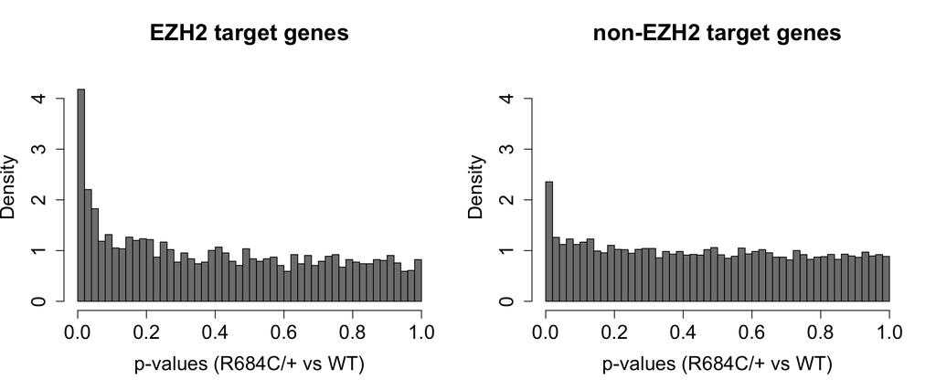

```r
par(mfrow=c(1,2))

hist(res$pvalue[which(rownames(res) %in% mouse.target.all$mouse)],
     freq=FALSE, breaks=50,
     xlab='p-values (R684C/+ vs WT)',
     main='EZH2 target genes',
     ylim=c(0,4.5),
     col='gray50',
     cex.lab=1.5,
     cex.axis=1.5,
     cex.main=1.75)

hist(res$pvalue[!(rownames(res) %in% mouse.target.all$mouse)],
     freq=FALSE, breaks=50,
     xlab='p-values (R684C/+ vs WT)',
     main='non-EZH2 target genes',
     ylim=c(0,4.5),
     col='gray50',
     cex.lab=1.5,
     cex.axis=1.5,
     cex.main=1.75)
```